# Insights for HIV Interventions among Millennials

## Try Random Forest

```python
# random forest
from numpy import mean
from sklearn.datasets import make_classification
from sklearn.model_selection import cross_val_score
from sklearn.model_selection import RepeatedStratifiedKFold
from sklearn.ensemble import RandomForestClassifier
```

```python
# generate data
df2_labels = np.array(df2.pop('x.aidtst4'))
df2_features = np.array(df2)
```

```python
# define model
model2 = RandomForestClassifier(n_estimators=10)
# define evaluation procedure
cv = RepeatedStratifiedKFold(n_splits=10, n_repeats=3, random_state=1)
```

```python
# evaluate model
scores = cross_val_score(model2, df2_features, df2_labels, scoring='roc_auc', cv=cv, n_jobs=-1)
accuracy2 = cross_val_score(model2, df2_features, df2_labels, scoring='accuracy', cv=cv, n_jobs=-1)
# summarize performance
print('Mean Accuracy: %.3f' % mean(accuracy2))
print('Mean ROC AUC: %.3f' % mean(scores))
```

```
Mean Accuracy: 0.641
Mean ROC AUC: 0.694
```

For HIV testing, DNN performed much better than random forest, with a ROC-AUC of 0.74 compared to 0.69, and the accuracy around 0.75 compared to 0.64 from random forest.

### Feature Importance from Random Forest (Plotted in R)

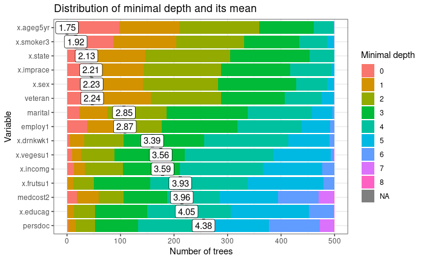

The plot above shows the distribution of minimal depth for top 15 variables based on mean minimal depth. Age, smoking status, the state where the participant lives in, race and sex are the top characteristics related to HIV testing. On average, age and smoking status appears with a minimal depth less than 2. These features agrees with previous literature. However, access to primary health care provider is not as important as it ranks 15 in this list. Urban/rural status is not even on this list. Based on the random forest results, these two characteristics are less influential to HIV testing compared to others.

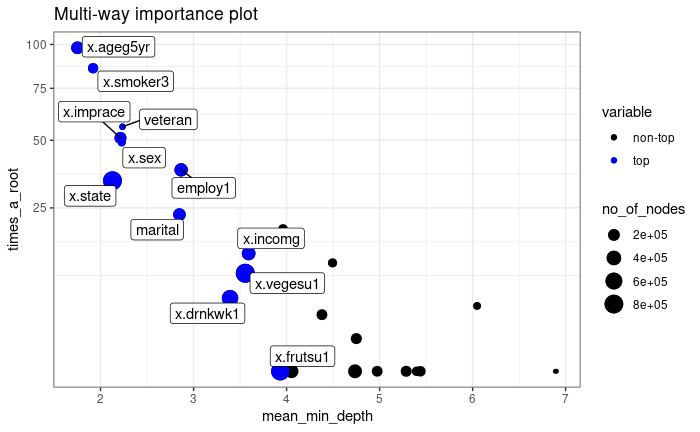

To further explore variable importance measures, a multiway importance plot was created as above. It gives us a similar result that age and smoking status are the most influential characteristics when it comes to HIV testing. And urban/rural status and access to priumary care provider are not as important compared to other features.

## Discussion and Conclusion

I used both DNN and random forest to answer the research question. For an imbalanced outcome, HIV risk behaviors, random forest performed slightly better than DNN in accuracy and precision. For a balanced outcome, DNN performed much better than random forest.The important features for HIV testing identified by random forest was consistent with previous literature and provided important insights for the identification of targets and strategy design for future interventions.

This project used BRFSS data-a large, nationally representative survey that included the millennial population. BRFSS data included over over 80,000 millennials in 2019. However, in the survey questions, BRFSS did not include granular questions about HIV risk behavior, and the two outcomes of interest asked about different reference time periods (ever for HIV testing versus in the past year for HIV risk behavior). This difference may have resulted in a specification error of the analysis since I could not evaluate if HIV risk behavior or HIV testing happened when the individual had a primary care physician. Meanwhile, the level of geographic information in BRFSS data does not allow for a concentrated investigation of the individuals living in the high-risk regions designated by CDC. Therefore, these results may not represent those populations. The one wave of BRFSS used is a cross-sectional dataset, indicating that no causal inference could be made in this analysis.

As a telephoen survey, BRFSS suffers from self-reporting bias, where the respondents may not answer the questions based on fact, but on social desirability. As HIV related questions are considered sentitive, and the risk behaviors BRFSS asked about are stigmatized behaviors, the impact of self-reporting bias cannot be ignored. It may lead to unit non-response, introducing nonresponse error. Most likely, the prevalence of individuals with HIV risk behavior would be higher than the prevalence from the survey sample, which could have thrown off the classification process.

## References

1. CDC. HIV and Youth. [https://www.cdc.gov/hiv/group/age/youth/index.html](https://urldefense.com/v3/__https://www.cdc.gov/hiv/group/age/youth/index.html__;!!KGKeukY!gZTZPCc5hGGOe4U5syrw--8wW0LFxA4Nj3ktmCQgGqQ537ZrZxoxhEo9S9kjtC1I$)
2. Peters PJ, Pontones P, Hoover KW, et al. HIV infection linked to injection use of oxymorphone in Indiana, 2014-2015. N Engl J Med. 2016;375(3):229-239. doi:10.1056/NEJMoa1515195
3. Colegrove A. Number of HIV cases grows to 80 in Cabell County. 2019. [https://www.wsaz.com/content/news/HIV-cluster-confirmed-in-Cabell-County-506708841.html](https://urldefense.com/v3/__https://www.wsaz.com/content/news/HIV-cluster-confirmed-in-Cabell-County-506708841.html__;!!KGKeukY!gZTZPCc5hGGOe4U5syrw--8wW0LFxA4Nj3ktmCQgGqQ537ZrZxoxhEo9S-KTsYsR$).
4. DeMio T. CDC called in to investigate HIV surges in the Cincinnati region. Cincinnati Enquirer. https://www.cincinnati.com/story/news/2018/10/24/ohio-kentucky-ask-cdc-help-hiv-cases-linked-injected-drugs-rise-cincinnati/1684956002/. Published October 24, 2018.
5. CDC. Vulnerable Counties and Jurisdictions Experiencing or At-Risk of Outbreaks. [https://www.cdc.gov/pwid/vulnerable-counties-data.html](https://urldefense.com/v3/__https://www.cdc.gov/pwid/vulnerable-counties-data.html__;!!KGKeukY!gZTZPCc5hGGOe4U5syrw--8wW0LFxA4Nj3ktmCQgGqQ537ZrZxoxhEo9S5GOy0qY$)
6. Dall T, Reynolds R, Jones K, Chakrabarti R, Iacobucci W. The Complexities of Physician Supply and Demand: Projections from 2017 to 2032. Assoc Am Med Coll. 2019:86. https://www.aamc.org/system/files/c/2/31-2019_update_-_the_complexities_of_physician_supply_and_demand_-_projections_from_2017-2032.pdf.
7. Kaiser Health Tracking Poll - July 2018: Changes to the Affordable Care Act; Health Care in the 2018 Midterms and the Supreme Court. Kaiser Family Foundation. https://www.kff.org/health-reform/poll-finding/kaiser-health-tracking-poll-july-2018-changes-to-the-affordable-care-act-health-care-in-the-2018-midterms-and-the-supreme-court/. Published 2018.
8. Kishore S, Hayden M, Rich J. Lessons from Scott County - Progress or paralysis on harm reduction? N Engl J Med. 2019;380(21):1988-1990. doi:10.1056/NEJMp1901276